# Crime and Policing Expenditures Exploratory Questions

In this exercise we'll be examining the relationship between crime and policing expenditures using county-level data from Massachusetts. In particular, we're hoping to answer the question "Is there a substantial relationship between crime and policing expenditures?"

## Exercises

### Exercise 1

Begin by downloading the data for this exercise from https://github.com/nickeubank/MIDS_Data/blob/master/descriptive_exercise/crime_expend_MA.csv (just go to `github.com/nickeubank/MIDS_Data`, then go to `descriptive_exercise` and get `crime_expend_MA.csv` if you don't want to type all that).

### Exercise 2

This data includes monthly data on both each county's policing expenditures (`policeexpenditures` as share of county budget) and an index of crime (`crimeindex`, scaled 0-100) from 1990 to late 2001.

In these exercises, we'll be focusing on just two counties -- `county_code` 4 and 10.

First, for each of these two counties, calculate the mean expenditure level and mean crimeindex score (i.e. calculate both means separately for each county).

Just to make sure we're practicing applied skills—use a loop to calculate your means and print your results nicely! So you should get output like this (though obviously with different numbers—I'm not gonna give you the answer!):

```
for county 4, average policing expenditure is 23.7 and average crime index is 75.83
for county 10, average policing expenditure is 62.15 and average crime index is 55.88
```

```python
import pandas as pd
import numpy as np

bd = pd.read_csv(
    "https://github.com/nickeubank/MIDS_Data/raw/master/descriptive_exercise/crime_expend_MA.csv"
)
bd_s = bd[bd["county_code"].isin([4, 10])]
```

```python
for i in bd_s["county_code"].unique():
    bd_loop = bd_s[bd_s["county_code"] == i]
    mean_police = bd_loop["policeexpenditures"].mean()
    mean_crime = bd_loop["crimeindex"].mean()
    print(
        f"for county {i}, average policing expenditure is {mean_police:.2f} and average crime index is {mean_crime:.2f}"
    )
```

```
for county 10, average policing expenditure is 54.24 and average crime index is 47.77
for county 4, average policing expenditure is 54.26 and average crime index is 47.83
```

### Exercise 3

Now calculate the standard deviation of both expenditures and crime for these two counties.

```python
for i in bd_s["county_code"].unique():
    bd_loop = bd_s[bd_s["county_code"] == i]
    sd_police = bd_loop["policeexpenditures"].std()
    sd_crime = bd_loop["crimeindex"].std()
    print(
        f"for county {i}, the standard deviation of policing expenditure is {sd_police:.2f} and the standard deviation of crime index is {sd_crime:.2f}"
    )
```

```
for county 10, the standard deviation of policing expenditure is 16.68 and the standard deviation of crime index is 27.00
for county 4, the standard deviation of policing expenditure is 16.77 and the standard deviation of crime index is 26.94
```

### Exercise 4

Now calculate the correlation between `policeexpenditures` and `crimeindex` for both of these counties (again, output the correlations with nicely formatted and labelled statements!)

```python
for i in bd_s["county_code"].unique():
    bd_loop = bd_s[bd_s["county_code"] == i]
    corr_pc = bd_loop["policeexpenditures"].corr(bd_loop["crimeindex"])
    print(
        f"for county {i}, the correlation of policing expenditure and crime index is {corr_pc:.2f}"
    )
```

```
for county 10, the correlation of policing expenditure and crime index is -0.06
for county 4, the correlation of policing expenditure and crime index is -0.06
```

```python
bd_s[bd_s["county_code"] == 4]
```

|  | months | county_code | crimeindex | policeexpenditures | month | year |
| --- | --- | --- | --- | --- | --- | --- |
| 7 | 0 | 4 | 97.1795 | 55.3846 | 1 | 1990 |
| 20 | 1 | 4 | 96.0256 | 51.5385 | 2 | 1990 |
| 33 | 2 | 4 | 94.4872 | 46.1538 | 3 | 1990 |
| 46 | 3 | 4 | 91.4103 | 42.8205 | 4 | 1990 |
| 59 | 4 | 4 | 88.3333 | 40.7692 | 5 | 1990 |
| ... | ... | ... | ... | ... | ... | ... |
| 1788 | 137 | 4 | 25.3846 | 39.4872 | 6 | 2001 |
| 1801 | 138 | 4 | 41.5385 | 91.2821 | 7 | 2001 |
| 1814 | 139 | 4 | 95.7692 | 50.0000 | 8 | 2001 |
| 1827 | 140 | 4 | 95.0000 | 47.9487 | 9 | 2001 |
| 1840 | 141 | 4 | 92.6923 | 44.1026 | 10 | 2001 |

142 rows × 6 columns

### Exercise 5

Based on your results up to this point, what would you guess about whether policing reduces crime? (I know -- this is just a descriptive statistics, and correlation does not imply causality. But what would you infer if this was all you knew?

> The correlation for both counties is similar with a negative value of -0.06, from this negative relation we can imply that as policy expenditure increases, crime rate diminishes. However, as the correlation is very low: -0.06 very small so this impact may not be singificant.

### Exercise 6

Given what you've seen up till now, would you infer that county 4 and county 10 have a similar relationship between crime and police expenditures?

> Having almost the same correlation indicates that the linear relationship between the crime and policy moves in the same way, indicating a similar relationship. However, although the mean and standard deviations for both counties are similar, it is necessary to visualize the distribution of the values to understand if there are any key differences.

### Exercise 7

Now plot histograms of `policeexpenditures` for both county 4 and county 10. Do the results change you impression of the similarity of county 4 and county 10?

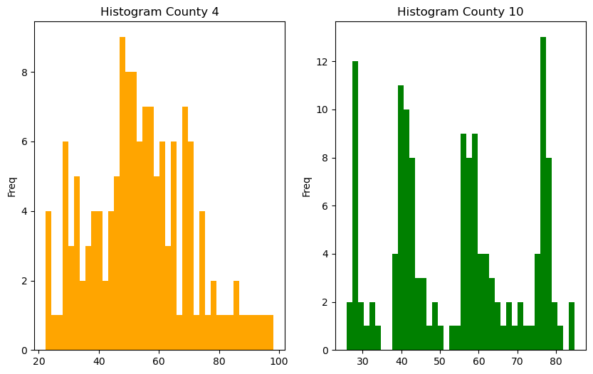

```python
import seaborn as sns
import matplotlib.pyplot as plt
import warnings

warnings.simplefilter(action="ignore", category=FutureWarning)

fig, (ax1, ax2) = plt.subplots(1, 2, figsize=(10, 6))  # nrows, ncols of axes
plt.sca(ax1)
plt.hist(bd_s[bd_s["county_code"] == 4]["policeexpenditures"], bins=40, color="orange")
plt.ylabel("Freq")
plt.title("Histogram County 4")
plt.sca(ax2)
plt.hist(bd_s[bd_s["county_code"] == 10]["policeexpenditures"], bins=40, color="green")
plt.ylabel("Freq")
plt.title("Histogram County 10")
```

> yes

### Exercise 8

Finally, create a scatter plot of the relationship between crime and police expenditures for each county (e.g. crime on one axis, police expenditures on the other). Does this change your sense of how similar these are?

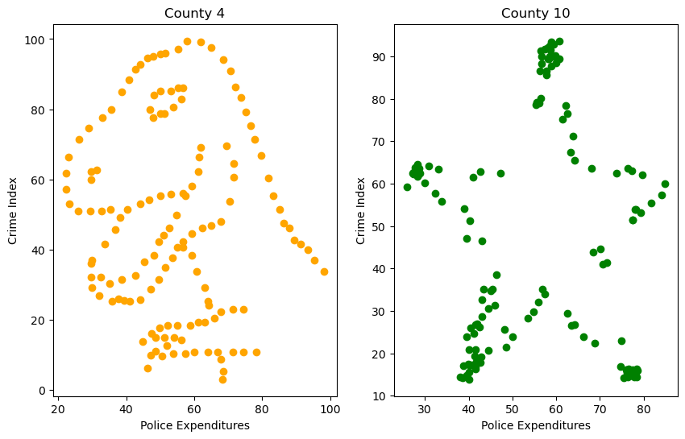

```python
fig, (ax1, ax2) = plt.subplots(1, 2, figsize=(10, 6))  # nrows, ncols of axes
plt.sca(ax1)
plt.scatter(
    bd_s[bd_s["county_code"] == 4]["policeexpenditures"],
    bd_s[bd_s["county_code"] == 4]["crimeindex"],
    color="orange",
)
plt.xlabel("Police Expenditures")
plt.ylabel("Crime Index")
plt.title("County 4")
plt.sca(ax2)
plt.scatter(
    bd_s[bd_s["county_code"] == 10]["policeexpenditures"],
    bd_s[bd_s["county_code"] == 10]["crimeindex"],
    color="green",
)
plt.xlabel("Police Expenditures")
plt.ylabel("Crime Index")
plt.title("County 10")
```

> yes

## After you have answered...

Read this discussion page.

### Exercise 9

Write a loop that plots the relationship between police expenditures and crimeindex for all 13 counties in the dataset separately!

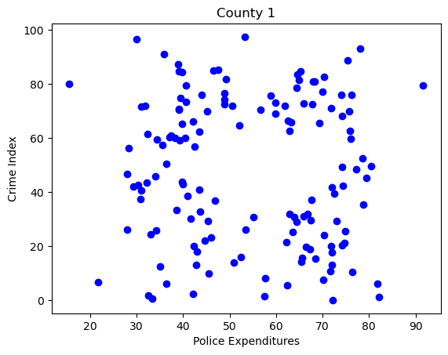

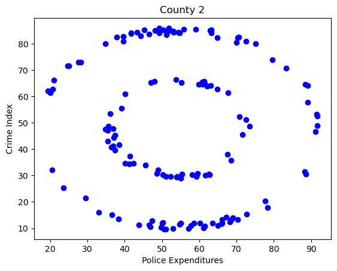

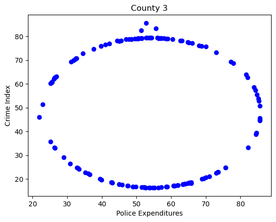

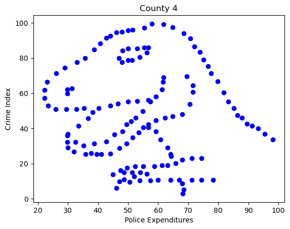

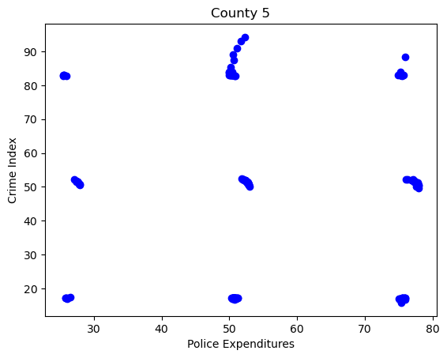

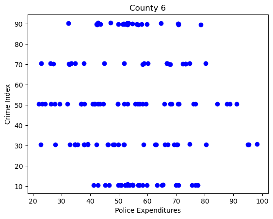

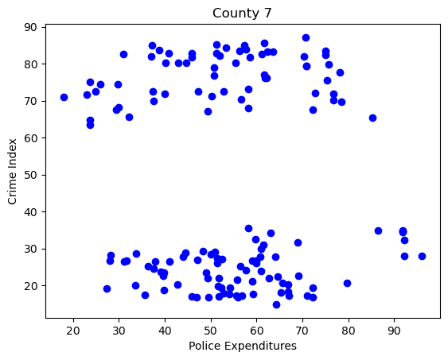

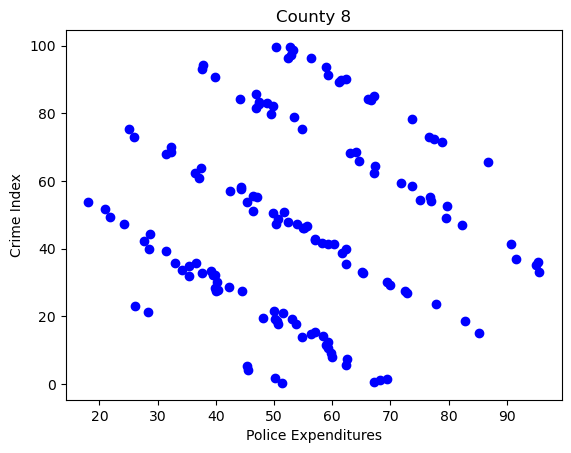

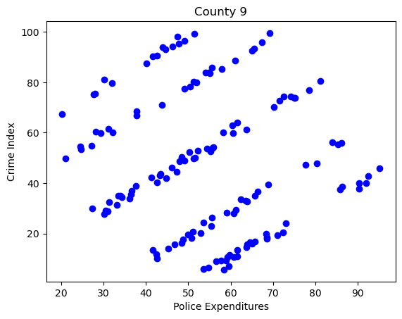

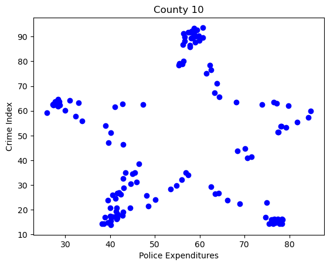

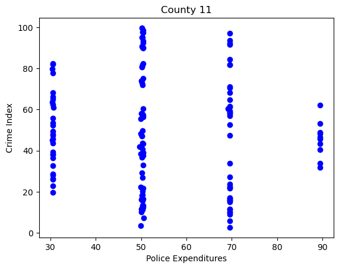

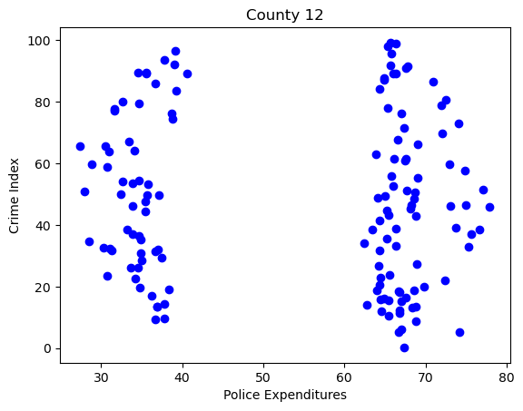

[1 more figures not shown]

```python
for i in range(1, 14):
    plt.figure()
    plt.scatter(
        bd[bd["county_code"] == i]["policeexpenditures"],
        bd[bd["county_code"] == i]["crimeindex"],
        color="blue",
    )
    plt.xlabel("Police Expenditures")
    plt.ylabel("Crime Index")
    plt.title(f"County {i}")
plt.show()
```